# Analyzing overdispersed count data with the mixpoissonreg package

Wagner Barreto-Souza and Alexandre B. Simas

2021-03-08

# Description of the dataset

We will consider the dataset studied in [Barreto-Souza and Simas (2016)](https://doi.org/10.1007/s11222-015-9601-6). The motivation for this study was to assess the attendance of high school students with respect to their gender, math score and which program they are enrolled. The data consists on 314 high school juniors from two urban high schools. The response variable, denoted by *y*, and the covariates of interest are:

- *y*: number of days absent;
- *gender*: sex (0=female and 1=male);
- *math*: standardized math score for each student;
- *academic* : indicator of academic program;
- *vocational*: indicator of vocational program.

# Model fitting and inference

It is well-known (see, for instance, https://stats.idre.ucla.edu/r/dae/negative-binomial-regression/) that the Poisson regression is not adequate for fitting this dataset. They also conclude that, when compared to the Poisson regression model, the Negative Binomial is more adequate. Therefore, this indicates that the data is overdispersed.

We will assume that the response variables $Y_i\sim MP(\mu_i, \phi_i)$, that is, that each $Y_i$ follows a mixed possion distribution with mean $\mu_i$ and precision parameter $\phi_i$.

We assume the following regression structures for the mean and precision parameters:

$$\log \mu_i = \beta_0 + \beta_1 {\tt gender}_i + \beta_2 {\tt math}_i + \beta_3 {\tt academic}_i + \beta_4 {\tt vocational}_i$$
and

$$\log \phi_i = \alpha_0 + \alpha_1 {\tt gender}_i + \alpha_2 {\tt math}_i + \alpha_3 {\tt academic}_i + \alpha_4 {\tt vocational}_i.$$
Let us fit this model under the assumption of Negative Binomial (NB) and Poisson Inverse Gaussian (PIG) distributions. In this vignette (for CRAN), we fit using direct maximization of the likelihood to reduce computational cost.

```r
library(mixpoissonreg)

fit_nb_full <- mixpoissonregML(daysabs ~ gender + math + prog | gender + math + prog,
                             model = "NB", data = Attendance)

fit_pig_full <- mixpoissonregML(daysabs ~ gender + math + prog | gender + math + prog,
                             model = "PIG", data = Attendance)
```

The summary for the NB-regression fitting is:

```r
summary(fit_nb_full)
```

```
#>
#> Negative Binomial Regression - Maximum-Likelihood Estimation
#>
#> Call:
#> mixpoissonregML(formula = daysabs ~ gender + math + prog | gender +
#>     math + prog, data = Attendance, model = "NB")
#>
#>
#> Pearson residuals:
#>      RSS      Min       1Q   Median       3Q      Max
#> 322.0172  -1.1751  -0.6992  -0.3600   0.3014   4.7178
#>
#> Coefficients modeling the mean (with  link):
#>                 Estimate Std.error z-value Pr(>|z|)
#> (Intercept)     2.746123  0.147412  18.629  < 2e-16 ***
#> gendermale     -0.245113  0.117967  -2.078  0.03773 *
#> math           -0.006617  0.002317  -2.856  0.00429 **
#> progAcademic   -0.425983  0.132144  -3.224  0.00127 **
#> progVocational -1.269755  0.174444  -7.279 3.37e-13 ***
#>
#> Coefficients modeling the precision (with  link):
#>                 Estimate Std.error z-value Pr(>|z|)
#> (Intercept)     1.414227  0.343243   4.120 3.79e-05 ***
#> gendermale     -0.208397  0.203692  -1.023 0.306262
#> math           -0.005123  0.004181  -1.225 0.220457
#> progAcademic   -1.084418  0.305479  -3.550 0.000385 ***
#> progVocational -1.422051  0.343811  -4.136 3.53e-05 ***
#> ---
#> Signif. codes:  0 '***' 0.001 '**' 0.01 '*' 0.05 '.' 0.1 ' ' 1
#>
#> Efron's pseudo R-squared:  0.1860887
#> Number of function calls by 'optim' = 4
```

For the PIG-regressionm, the summary is

```r
summary(fit_pig_full)
```

```
#>
#> Poisson Inverse Gaussian Regression - Maximum-Likelihood Estimation
#>
#> Call:
#> mixpoissonregML(formula = daysabs ~ gender + math + prog | gender +
#>     math + prog, data = Attendance, model = "PIG")
#>
#>
#> Pearson residuals:
#>      RSS      Min       1Q   Median       3Q      Max
#> 239.1115  -1.0826  -0.6059  -0.3064   0.2517   4.1186
#>
#> Coefficients modeling the mean (with  link):
#>                 Estimate Std.error z-value Pr(>|z|)
#> (Intercept)     2.750165  0.165450  16.622  < 2e-16 ***
#> gendermale     -0.251027  0.136903  -1.834  0.06671 .
#> math           -0.006728  0.002680  -2.510  0.01206 *
#> progAcademic   -0.422607  0.148513  -2.846  0.00443 **
#> progVocational -1.260295  0.203467  -6.194 5.86e-10 ***
#>
#> Coefficients modeling the precision (with  link):
#>                 Estimate Std.error z-value Pr(>|z|)
#> (Intercept)     1.210080  0.438390   2.760 0.005775 **
#> gendermale     -0.114740  0.304696  -0.377 0.706493
#> math           -0.005690  0.006098  -0.933 0.350830
#> progAcademic   -1.282477  0.386312  -3.320 0.000901 ***
#> progVocational -1.608476  0.475594  -3.382 0.000720 ***
#> ---
#> Signif. codes:  0 '***' 0.001 '**' 0.01 '*' 0.05 '.' 0.1 ' ' 1
#>
#> Efron's pseudo R-squared:  0.1861621
#> Number of function calls by 'optim' = 9
```

These summaries suggest that *gender* and *math* covariates are not significant to explain the precision parameter. So we will obtain fits for the NB and PIG regressions without these variables for the precision paramters, then we will perform Wald and likelihood-ratio tests to confirm that indeed they are not significant.

```r
fit_nb_red <- mixpoissonregML(daysabs ~ gender + math + prog | prog,
                             model = "NB", data = Attendance)

fit_pig_red <- mixpoissonregML(daysabs ~ gender + math + prog | prog,
                             model = "PIG", data = Attendance)
```

Let us check the summaries for these regressions:

```r
summary(fit_nb_red)
```

```
#>
#> Negative Binomial Regression - Maximum-Likelihood Estimation
#>
#> Call:
#> mixpoissonregML(formula = daysabs ~ gender + math + prog | prog,
#>     data = Attendance, model = "NB")
#>
#>
#> Pearson residuals:
#>      RSS      Min       1Q   Median       3Q      Max
#> 323.9340  -1.0684  -0.7203  -0.3660   0.3062   4.8766
#>
#> Coefficients modeling the mean (with  link):
#>                 Estimate Std.error z-value Pr(>|z|)
#> (Intercept)     2.752203  0.152251  18.077  < 2e-16 ***
#> gendermale     -0.256901  0.116816  -2.199  0.02786 *
#> math           -0.006791  0.002271  -2.989  0.00279 **
#> progAcademic   -0.423978  0.132089  -3.210  0.00133 **
#> progVocational -1.238641  0.172941  -7.162 7.94e-13 ***
#>
#> Coefficients modeling the precision (with  link):
#>                Estimate Std.error z-value Pr(>|z|)
#> (Intercept)      1.1185    0.2784   4.017 5.88e-05 ***
#> progAcademic    -1.0925    0.3075  -3.552 0.000382 ***
#> progVocational  -1.5270    0.3396  -4.496 6.91e-06 ***
#> ---
#> Signif. codes:  0 '***' 0.001 '**' 0.01 '*' 0.05 '.' 0.1 ' ' 1
#>
#> Efron's pseudo R-squared:  0.1861221
#> Number of function calls by 'optim' = 4
```

and

```r
summary(fit_pig_red)
```

```
#>
#> Poisson Inverse Gaussian Regression - Maximum-Likelihood Estimation
#>
#> Call:
#> mixpoissonregML(formula = daysabs ~ gender + math + prog | prog,
#>     data = Attendance, model = "PIG")
#>
#>
#> Pearson residuals:
#>      RSS      Min       1Q   Median       3Q      Max
#> 239.2987  -1.0042  -0.6101  -0.3107   0.2734   4.2816
#>
#> Coefficients modeling the mean (with  link):
#>                 Estimate Std.error z-value Pr(>|z|)
#> (Intercept)     2.805150  0.162182  17.296  < 2e-16 ***
#> gendermale     -0.282333  0.122772  -2.300  0.02147 *
#> math           -0.007771  0.002398  -3.240  0.00120 **
#> progAcademic   -0.422885  0.148011  -2.857  0.00428 **
#> progVocational -1.215877  0.197261  -6.164  7.1e-10 ***
#>
#> Coefficients modeling the precision (with  link):
#>                Estimate Std.error z-value Pr(>|z|)
#> (Intercept)      0.9277    0.3308   2.805 0.005038 **
#> progAcademic    -1.2799    0.3853  -3.322 0.000894 ***
#> progVocational  -1.7440    0.4506  -3.870 0.000109 ***
#> ---
#> Signif. codes:  0 '***' 0.001 '**' 0.01 '*' 0.05 '.' 0.1 ' ' 1
#>
#> Efron's pseudo R-squared:  0.1858035
#> Number of function calls by 'optim' = 6
```

Now, let us perform a Wald test:

```r
lmtest::waldtest(fit_nb_red, fit_nb_full)
```

```
#> Wald test
#>
#> Model 1: daysabs ~ gender + math + prog | prog
#> Model 2: daysabs ~ gender + math + prog | gender + math + prog
#>   Res.Df Df  Chisq Pr(>Chisq)
#> 1    306
#> 2    304  2 2.4149      0.299
```

and

```r
lmtest::waldtest(fit_pig_red, fit_pig_full)
```

```
#> Wald test
#>
#> Model 1: daysabs ~ gender + math + prog | prog
#> Model 2: daysabs ~ gender + math + prog | gender + math + prog
#>   Res.Df Df Chisq Pr(>Chisq)
#> 1    306
#> 2    304  2 0.932     0.6275
```

Now, let us perform likelihood tests:

```r
lmtest::lrtest(fit_nb_red, fit_nb_full)
```

```
#> Likelihood ratio test
#>
#> Model 1: daysabs ~ gender + math + prog | prog
#> Model 2: daysabs ~ gender + math + prog | gender + math + prog
#>   #Df  LogLik Df  Chisq Pr(>Chisq)
#> 1   8 -854.41
#> 2  10 -853.20  2 2.4084     0.2999
```

and

```r
lmtest::lrtest(fit_pig_red, fit_pig_full)
```

```
#> Likelihood ratio test
#>
#> Model 1: daysabs ~ gender + math + prog | prog
#> Model 2: daysabs ~ gender + math + prog | gender + math + prog
#>   #Df  LogLik Df  Chisq Pr(>Chisq)
#> 1   8 -857.52
#> 2  10 -857.05  2 0.9506     0.6217
```

The above tests indicate that, indeed, *gender* and *math* are not significant for the precision parameter. So we will work with the reduced models.

Let us also build a small data frame containing the estimated mean, $\widehat{\mu}$, for some combinations of the covariates. First for the NB regression model:

```r
library(tidyr)
library(dplyr)

gender <- c("female", "male")
prog <- c("Academic", "General", "Vocational")
math <- c(0, 99)

new_cov <- crossing(gender, prog, math)

pred_values_nb <- predict(fit_nb_red, newdata = new_cov)

bind_cols(new_cov, "Predicted_Means_NB" = pred_values_nb)
```

```
#> # A tibble: 12 x 4
#>    gender prog        math Predicted_Means_NB
#>    <chr>  <chr>      <dbl>              <dbl>
#>  1 female Academic       0              15.7
#>  2 female Academic      99               8.00
#>  3 female General        0              10.3
#>  4 female General       99               5.24
#>  5 female Vocational     0               4.54
#>  6 female Vocational    99               2.32
#>  7 male   Academic       0              12.1
#>  8 male   Academic      99               6.19
#>  9 male   General        0               7.94
#> 10 male   General       99               4.05
#> 11 male   Vocational     0               3.51
#> 12 male   Vocational    99               1.79
```

Now for the PIG regression model:

```r
pred_values_pig <- predict(fit_pig_red, newdata = new_cov)

bind_cols(new_cov, "Predicted_Means_PIG" = pred_values_pig)
```

```
#> # A tibble: 12 x 4
#>    gender prog        math Predicted_Means_PIG
#>    <chr>  <chr>      <dbl>               <dbl>
#>  1 female Academic       0               16.5
#>  2 female Academic      99                7.66
#>  3 female General        0               10.8
#>  4 female General       99                5.02
#>  5 female Vocational     0                4.90
#>  6 female Vocational    99                2.27
#>  7 male   Academic       0               12.5
#>  8 male   Academic      99                5.77
#>  9 male   General        0                8.17
#> 10 male   General       99                3.78
#> 11 male   Vocational     0                3.69
#> 12 male   Vocational    99                1.71
```

# Residual analysis

Let us fit the reduced models with envelopes. We will fit these models with the Pearson residual.

```r
set.seed(2021)
# We are fixing the seed for reproducibility
fit_nb_red_env <- mixpoissonregML(daysabs ~ gender + math + prog | prog,
                             model = "NB", data = Attendance, envelope = 20)

fit_pig_red_env <- mixpoissonregML(daysabs ~ gender + math + prog | prog,
                             model = "PIG", data = Attendance, envelope = 20)
```

Let us check the coverage of the envelopes for the NB fit:

```r
summary(fit_nb_red_env)
```

```
#>
#> Negative Binomial Regression - Maximum-Likelihood Estimation
#>
#> Call:
#> mixpoissonregML(formula = daysabs ~ gender + math + prog | prog,
#>     data = Attendance, model = "NB", envelope = 20)
#>
#>
#> Pearson residuals:
#>      RSS      Min       1Q   Median       3Q      Max
#> 323.9340  -1.0684  -0.7203  -0.3660   0.3062   4.8766
#>
#> Coefficients modeling the mean (with  link):
#>                 Estimate Std.error z-value Pr(>|z|)
#> (Intercept)     2.752203  0.152251  18.077  < 2e-16 ***
#> gendermale     -0.256901  0.116816  -2.199  0.02786 *
#> math           -0.006791  0.002271  -2.989  0.00279 **
#> progAcademic   -0.423978  0.132089  -3.210  0.00133 **
#> progVocational -1.238641  0.172941  -7.162 7.94e-13 ***
#>
#> Coefficients modeling the precision (with  link):
#>                Estimate Std.error z-value Pr(>|z|)
#> (Intercept)      1.1185    0.2784   4.017 5.88e-05 ***
#> progAcademic    -1.0925    0.3075  -3.552 0.000382 ***
#> progVocational  -1.5270    0.3396  -4.496 6.91e-06 ***
#> ---
#> Signif. codes:  0 '***' 0.001 '**' 0.01 '*' 0.05 '.' 0.1 ' ' 1
#>
#> Efron's pseudo R-squared:  0.1861221
#> Percentage of residuals within the envelope = 94.586
#> Number of function calls by 'optim' = 4
```

and for the PIG fit:

```r
summary(fit_pig_red_env)
```

```
#>
#> Poisson Inverse Gaussian Regression - Maximum-Likelihood Estimation
#>
#> Call:
#> mixpoissonregML(formula = daysabs ~ gender + math + prog | prog,
#>     data = Attendance, model = "PIG", envelope = 20)
#>
#>
#> Pearson residuals:
#>      RSS      Min       1Q   Median       3Q      Max
#> 239.2987  -1.0042  -0.6101  -0.3107   0.2734   4.2816
#>
#> Coefficients modeling the mean (with  link):
#>                 Estimate Std.error z-value Pr(>|z|)
#> (Intercept)     2.805150  0.162182  17.296  < 2e-16 ***
#> gendermale     -0.282333  0.122772  -2.300  0.02147 *
#> math           -0.007771  0.002398  -3.240  0.00120 **
#> progAcademic   -0.422885  0.148011  -2.857  0.00428 **
#> progVocational -1.215877  0.197261  -6.164  7.1e-10 ***
#>
#> Coefficients modeling the precision (with  link):
#>                Estimate Std.error z-value Pr(>|z|)
#> (Intercept)      0.9277    0.3308   2.805 0.005038 **
#> progAcademic    -1.2799    0.3853  -3.322 0.000894 ***
#> progVocational  -1.7440    0.4506  -3.870 0.000109 ***
#> ---
#> Signif. codes:  0 '***' 0.001 '**' 0.01 '*' 0.05 '.' 0.1 ' ' 1
#>
#> Efron's pseudo R-squared:  0.1858035
#> Percentage of residuals within the envelope = 95.8599
#> Number of function calls by 'optim' = 6
```

By looking at both coverages, the assumption of the response following a mixed Poisson distribution seems reasonable. Furthermore, both regressions seem to provide adequate fit.

Also, notice that, even though the fits seem adequate, their Efron’s $R^2$ are low, around 18%. This is due to the high overdispersion of the responses, together with the fact that the mean is not a good predictor for the response when using counting data. Therefore, for datasets with low Efron’s pseudo-$R^2$, such as this one, we recommend to use the mode. We plan on providing a function from prediction based on the mode in the future.

Let us check the diagnostic plots of the NB fit

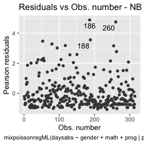

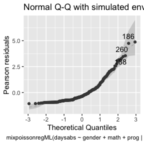

```r
autoplot(fit_nb_red_env, which = c(1,2))
```

and for the PIG fit

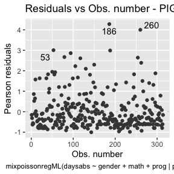

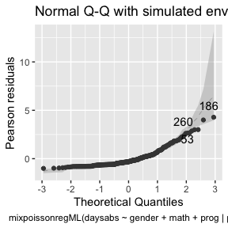

```r
autoplot(fit_pig_red_env, which = c(1,2))
```

Notice that in Residuals vs. Obs. number, the residuals appear to be randomly distributed, skewed, and with no noticeable trend. Thus, also suggesting an adequate fit, together with the quantile-quantile plot with simulated envelopes.

# Influence analysis

Let us begin with the global influence analysis. First, for the NB regression model:

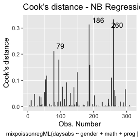

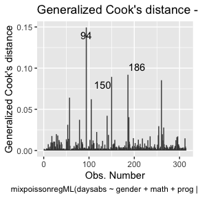

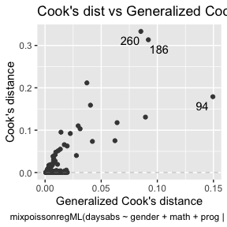

```r
autoplot(fit_nb_red, which = c(3,4,5))
```

Second, for the PIG regression model:

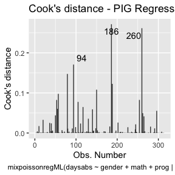

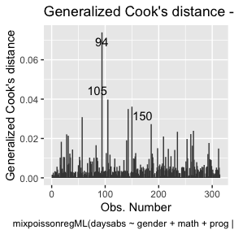

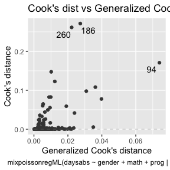

```r
autoplot(fit_pig_red, which = c(3,4,5))
```

```r
# Relative change for mean-related coefficients
(influence(fit_nb_red)$coefficients.mean[94,] -
   coefficients(fit_nb_red, parameters = "mean"))/
  coefficients(fit_nb_red, parameters = "mean")
```

```
#>    (Intercept)     gendermale           math   progAcademic progVocational
#>   -0.002686709   -0.012880493    0.017304268   -0.024445131   -0.010214972
```

```r
# Relative change for precision-related coefficients
(influence(fit_nb_red)$coefficients.precision[94,] -
    coefficients(fit_nb_red, parameters = "precision"))/
  coefficients(fit_nb_red, parameters = "precision")
```

```
#>    (Intercept)   progAcademic progVocational
#>     0.05282537     0.05408266     0.03869297
```

Now, for the PIG regression:

```r
# Relative change for mean-related coefficients
(influence(fit_pig_red)$coefficients.mean[94,] -
   coefficients(fit_pig_red, parameters = "mean"))/
  coefficients(fit_pig_red, parameters = "mean")
```

```
#>    (Intercept)     gendermale           math   progAcademic progVocational
#>   -0.001926612   -0.008484663    0.011184813   -0.018040366   -0.007643098
```

```r
# Relative change for precision-related coefficients
(influence(fit_pig_red)$coefficients.precision[94,] -
    coefficients(fit_pig_red, parameters = "precision"))/
  coefficients(fit_pig_red, parameters = "precision")
```

```
#>    (Intercept)   progAcademic progVocational
#>     0.04511487     0.03270183     0.02399838
```

We see that case # 94 mainly impacts the precision parameter estimates. Notice that for PIG regression models, the impact is less severe.

Let us check now the local influence.

First for the NB regression:

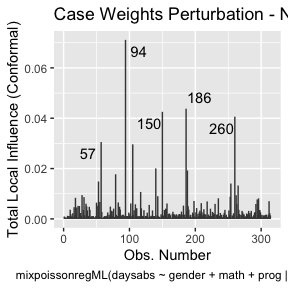

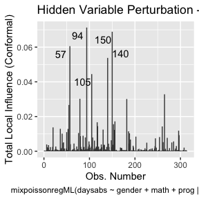

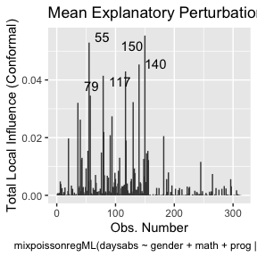

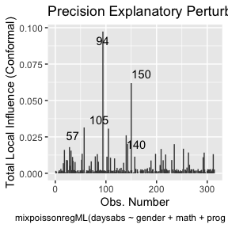

```r
local_influence_autoplot(fit_nb_red)
```

Now, for PIG regression:

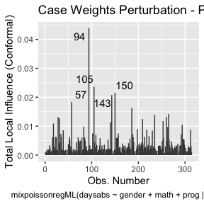

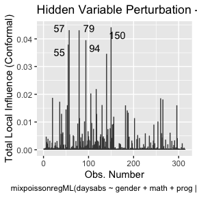

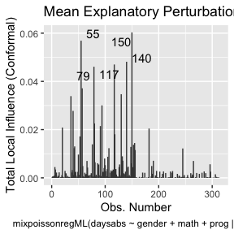

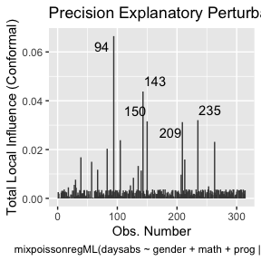

```r
local_influence_autoplot(fit_pig_red)
```

Let us check the influential observations along with their associated covariates and response values. First for the NB regression:

```r
inf_nb_tbl <- tidy_local_influence(fit_nb_red) %>% mutate(.index = row_number()) %>%
  pivot_longer(!.index, names_to = "perturbation", values_to = "curvature")
bench_nb_tbl <- local_influence_benchmarks(fit_nb_red) %>%
  pivot_longer(everything(), names_to = "perturbation", values_to = "benchmark")

inf_nb_bench_tbl <- left_join(inf_nb_tbl, bench_nb_tbl, by = "perturbation") %>%
  mutate(influential = curvature > benchmark) %>% filter(influential == TRUE) %>%
  select(-influential, -benchmark, -curvature)

data_nb_tbl <- augment(fit_nb_red) %>% mutate(.index = row_number()) %>%
  select(.index, daysabs, gender, math, prog)

influential_nb <- left_join(inf_nb_bench_tbl, data_nb_tbl, by = ".index")

influential_nb
```

```
#> # A tibble: 55 x 6
#>    .index perturbation             daysabs gender  math prog
#>     <int> <chr>                      <dbl> <fct>  <dbl> <fct>
#>  1     20 mean_explanatory              24 male       4 Academic
#>  2     20 simultaneous_explanatory      24 male       4 Academic
#>  3     36 mean_explanatory              28 female    20 Academic
#>  4     36 simultaneous_explanatory      28 female    20 Academic
#>  5     40 mean_explanatory              27 female    35 Academic
#>  6     40 simultaneous_explanatory      27 female    35 Academic
#>  7     55 hidden_variable               34 female     4 Academic
#>  8     55 mean_explanatory              34 female     4 Academic
#>  9     55 simultaneous_explanatory      34 female     4 Academic
#> 10     57 case_weights                  28 male       5 General
#> # … with 45 more rows
```

Let us check the number of unique influential observations:

```r
influential_nb %>% select(.index) %>% unique() %>% count()
```

```
#> # A tibble: 1 x 1
#>       n
#>   <int>
#> 1    22
```

Now for the PIG regression:

```r
inf_pig_tbl <- tidy_local_influence(fit_pig_red) %>% mutate(.index = row_number()) %>%
  pivot_longer(!.index, names_to = "perturbation", values_to = "curvature")
bench_pig_tbl <- local_influence_benchmarks(fit_pig_red) %>%
  pivot_longer(everything(), names_to = "perturbation", values_to = "benchmark")

inf_pig_bench_tbl <- left_join(inf_pig_tbl, bench_pig_tbl, by = "perturbation") %>%
  mutate(influential = curvature > benchmark) %>% filter(influential == TRUE) %>%
  select(-influential, -benchmark, -curvature)

data_pig_tbl <- augment(fit_pig_red) %>% mutate(.index = row_number()) %>%
  select(.index, daysabs, gender, math, prog)

influential_pig <- left_join(inf_pig_bench_tbl, data_pig_tbl, by = ".index")

influential_pig
```

```
#> # A tibble: 64 x 6
#>    .index perturbation             daysabs gender  math prog
#>     <int> <chr>                      <dbl> <fct>  <dbl> <fct>
#>  1     20 hidden_variable               24 male       4 Academic
#>  2     20 mean_explanatory              24 male       4 Academic
#>  3     20 simultaneous_explanatory      24 male       4 Academic
#>  4     28 case_weights                   0 female    21 Academic
#>  5     31 case_weights                   0 male       1 Academic
#>  6     36 hidden_variable               28 female    20 Academic
#>  7     36 mean_explanatory              28 female    20 Academic
#>  8     36 simultaneous_explanatory      28 female    20 Academic
#>  9     39 precision_explanatory          5 male       1 General
#> 10     40 mean_explanatory              27 female    35 Academic
#> # … with 54 more rows
```

Now, the number of unique influential observations for the PIG regression:

```r
influential_pig %>% select(.index) %>% unique() %>% count()
```

```
#> # A tibble: 1 x 1
#>       n
#>   <int>
#> 1    28
```

Let us check the informations of case # 94 for the NB and PIG regressions:

```r
influential_nb %>% filter(.index == 94)
```

```
#> # A tibble: 5 x 6
#>   .index perturbation             daysabs gender  math prog
#>    <int> <chr>                      <dbl> <fct>  <dbl> <fct>
#> 1     94 case_weights                  29 female    70 General
#> 2     94 hidden_variable               29 female    70 General
#> 3     94 mean_explanatory              29 female    70 General
#> 4     94 precision_explanatory         29 female    70 General
#> 5     94 simultaneous_explanatory      29 female    70 General
```

```r
influential_pig %>% filter(.index == 94)
```

```
#> # A tibble: 5 x 6
#>   .index perturbation             daysabs gender  math prog
#>    <int> <chr>                      <dbl> <fct>  <dbl> <fct>
#> 1     94 case_weights                  29 female    70 General
#> 2     94 hidden_variable               29 female    70 General
#> 3     94 mean_explanatory              29 female    70 General
#> 4     94 precision_explanatory         29 female    70 General
#> 5     94 simultaneous_explanatory      29 female    70 General
```

So, notice that case # 94 is a female, enrolled in the general program, with a high number of absences but with an unexpected high math score for this number of absences.

It is also noteworthy that case # 94 was considered influential for all local perturbation schemes.

Let us check the observations that were found influential for both models:

```r
ind_nb <- influential_nb %>% select(.index) %>% unique()

ind_pig <- influential_pig %>% select(.index) %>% unique()

ind_common <- intersect(ind_nb, ind_pig)

influential_nb %>% filter(.index %in% ind_common$.index) %>% select(-perturbation) %>% unique()
```

```
#> # A tibble: 20 x 5
#>    .index daysabs gender  math prog
#>     <int>   <dbl> <fct>  <dbl> <fct>
#>  1     20      24 male       4 Academic
#>  2     36      28 female    20 Academic
#>  3     40      27 female    35 Academic
#>  4     55      34 female     4 Academic
#>  5     57      28 male       5 General
#>  6     79      35 male       1 Academic
#>  7     80      23 female    21 Academic
#>  8     91      23 female    27 Academic
#>  9     94      29 female    70 General
#> 10    105      19 male      70 General
#> 11    117      35 female    35 Academic
#> 12    130      30 female    34 Academic
#> 13    140      30 female    27 General
#> 14    143       5 female     7 General
#> 15    150      34 female    29 General
#> 16    182      21 female    47 General
#> 17    186      16 male      81 Vocational
#> 18    235       3 female    67 General
#> 19    260      19 male      49 Vocational
#> 20    265      16 female    99 General
```

Now, let us check the influential observations for the NB regression that were not influential for the PIG regression:

```r
ind_nb_pig <- setdiff(ind_nb, ind_pig)

influential_nb %>% filter(.index %in% ind_nb_pig$.index) %>% select(-perturbation) %>% unique()
```

```
#> # A tibble: 2 x 5
#>   .index daysabs gender  math prog
#>    <int>   <dbl> <fct>  <dbl> <fct>
#> 1    118      16 female     8 General
#> 2    188      16 female    75 Vocational
```

Finally, the influential observations for the PIG regression that were not influential for the NB regression:

```r
ind_pig_nb <- setdiff(ind_pig, ind_nb)

influential_pig %>% filter(.index %in% ind_pig_nb$.index) %>% select(-perturbation) %>% unique()
```

```
#> # A tibble: 8 x 5
#>   .index daysabs gender  math prog
#>    <int>   <dbl> <fct>  <dbl> <fct>
#> 1     28       0 female    21 Academic
#> 2     31       0 male       1 Academic
#> 3     39       5 male       1 General
#> 4     83       3 female    84 General
#> 5    209       4 female    41 General
#> 6    213       4 female    63 General
#> 7    253       0 female    29 Academic
#> 8    263       3 male      43 General
```